# Enron Email Analysis

Vincent Messina

2023-11-28

```
## Number of emails exchanged in September 2001: 3762
```

```
## Number of emails exchanged in October 2001: 10796
```

```
## Average degree in September 2001: 38.20652
```

```
## Average degree in October 2001: 109.2826
```

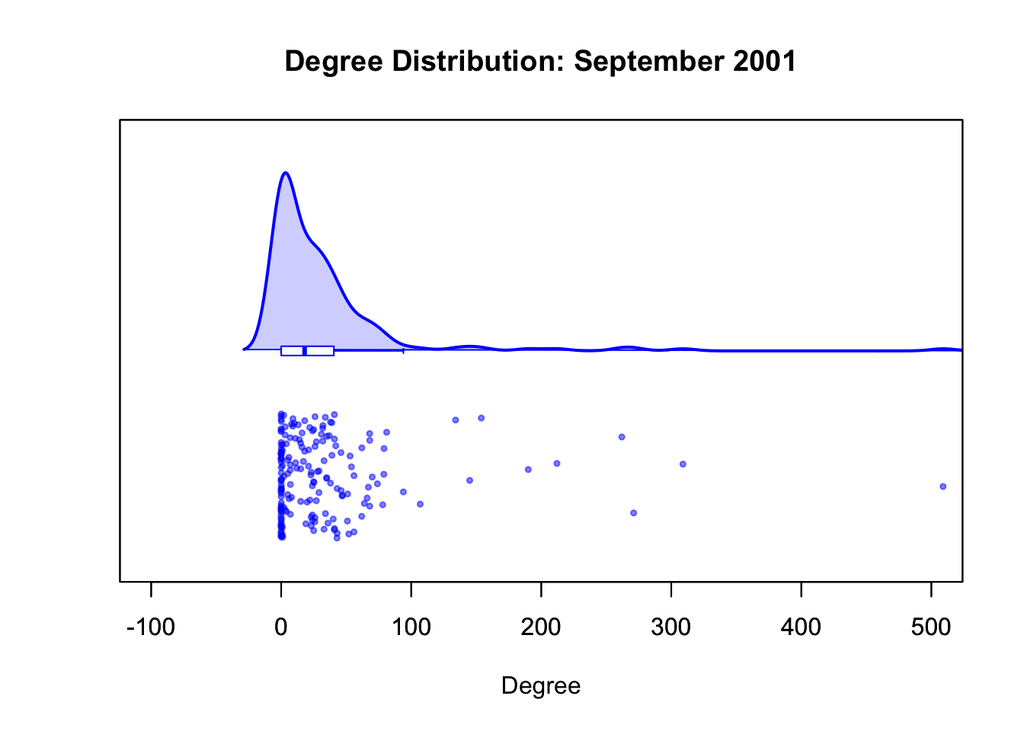

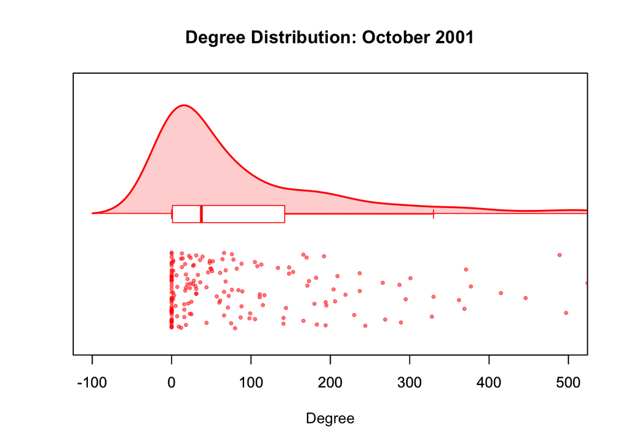

We could see in both months that the data is generally right skewed. This indicates that a large number of emails were transmitted from a small group of people possibly executives worrying about the impending scandal, while the rest of the staff carried on business as usual.

There are many accounts with 0 emails sent and that’s as expected not everyone necessarily sent or received emails that given month

```
## Density in September 2001: 0.01484913
```

```
## Density in October 2001: 0.02292706
```

We could see the data is quite right skewed in September. This indicates that a large number of emails were transmitted from a small group of people possibly executives worrying about the impending scandal, while the rest of the staff carried on business as usual

There are many accounts with 0 emails sent and that’s as expected not everyone necessarily sent or received emails that given month

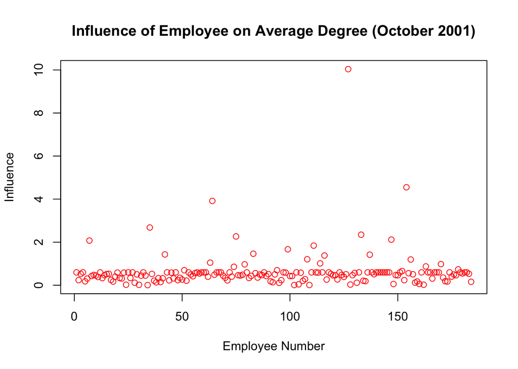

```
## The employee with the highest influence in October 2001 has the job title: In House Lawyer and is employee number: 127
```

# It makes snese that the In House Lawyer had the highest influence.

# They were likely involved in the decision making processes during the scandal.